# Assignment-2

Jiwon Park

2020 9 19

## Install Packages

```r
library(ggplot2)
library(cowplot)
library(googleway)
library(sf)
library(rnaturalearth)
library(rnaturalearthdata)
library(tidyverse)
library(ggspatial)
library(ggrepel)
library(viridis)
library(rgeos)
library(cartogram)
library(ggthemes)
library(devtools)
library(usmap)
```

## World Map

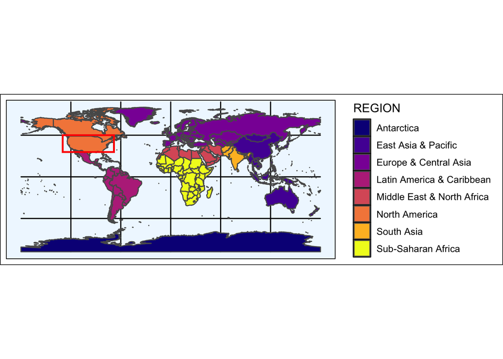

```r
world_map <- ne_countries(scale=50, returnclass="sf")
world_map_02 <- ggplot(world_map) +
  geom_sf(aes(fill = region_wb)) +
  theme_foundation() +
  geom_rect(xmin = -130, xmax = -68.01197, ymin = 30, ymax = 50,
     fill = NA, colour = "red", size = 0.7) +
  scale_fill_viridis_d(option = "plasma", name = "REGION") +
  theme(panel.background = element_rect(fill = "aliceblue"),
     panel.border = element_rect(fill = NA))

world_map_02
```

## Map of the States in the United States

```
## Scale on map varies by more than 10%, scale bar may be inaccurate
```

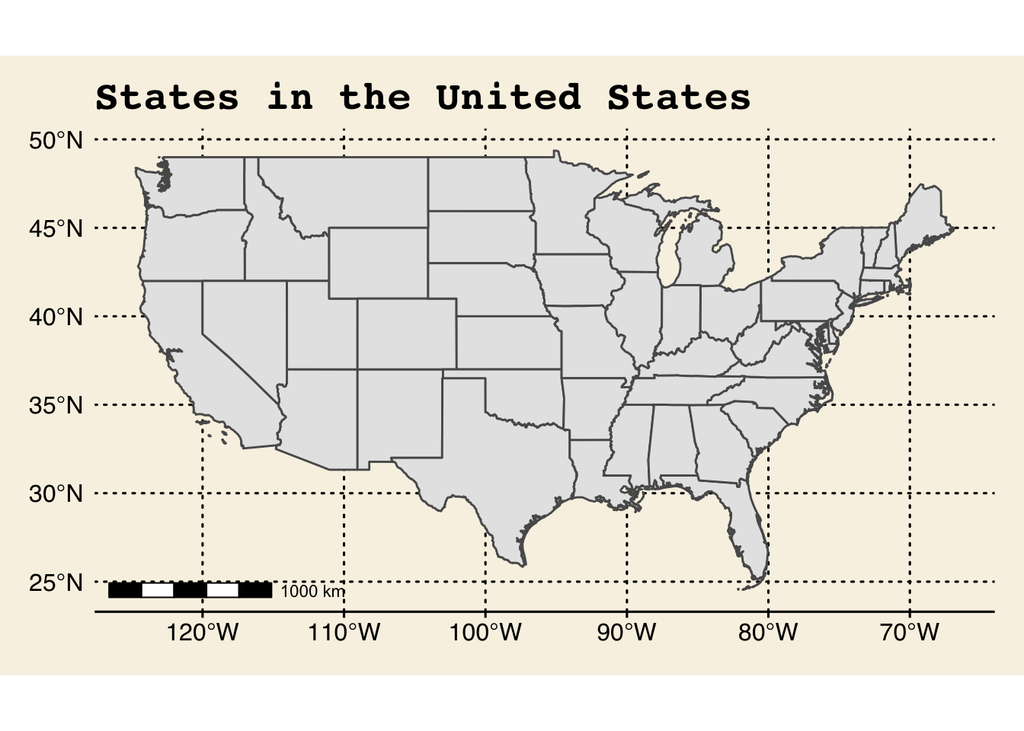

```r
US_states <- ne_states(country = "United States of America",
                       returnclass = "sf") %>%
  filter(name != "Alaska",
         name != "Hawaii")

US_map <- ggplot(US_states) +
  geom_sf() +
  theme_wsj() +
  xlab("Longitude") + ylab("Latitude") +
  ggtitle("States in the United States") +
  theme(plot.title = element_text(size = 20, face = "bold")) +
  annotation_scale()

US_map
```

## Three different Map Projections

### 1. Lambert Azimuthal Equal Area Projection (LAEA)

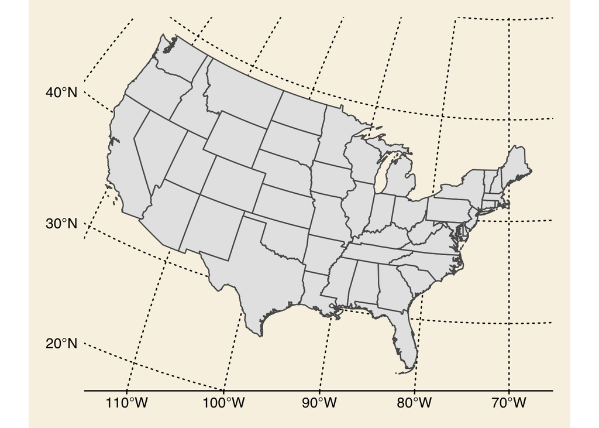

```r
USA_LAEA <- "+proj=laea + lon_0=-70 + lat_0=30 + x_0=0 +y_0=0 +ellps=GRS80 +units=m +no_defs "

ggplot(US_states) +
  geom_sf() +
  theme_wsj() +
  coord_sf(crs = USA_LAEA)
```

### 2. Transverse Mercator Projection (TMERC)

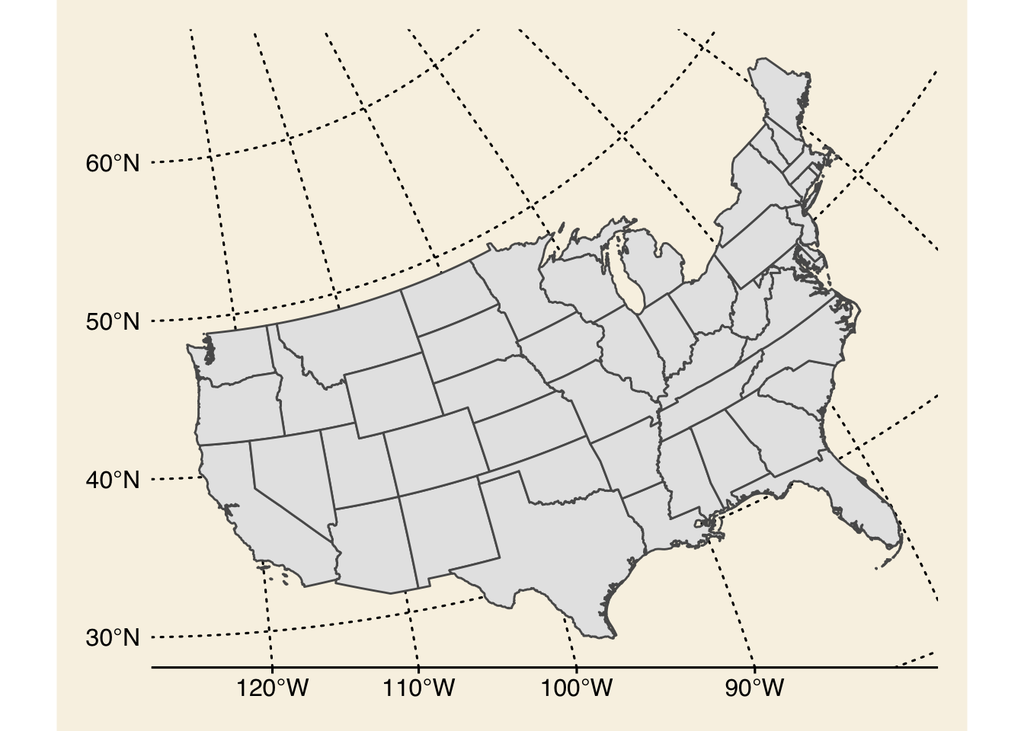

```r
USA_TMERC <- "+proj=tmerc + lat_0=20 +lon_0=-130 +k_0=1 +x_0=0 +y_0=0 +ellps=bessel + no_defs"

ggplot(US_states) +
  geom_sf() +
  theme_wsj() +
  coord_sf(crs = USA_TMERC)
```

### 3. Lambert Conformal Conic projection (LCC)

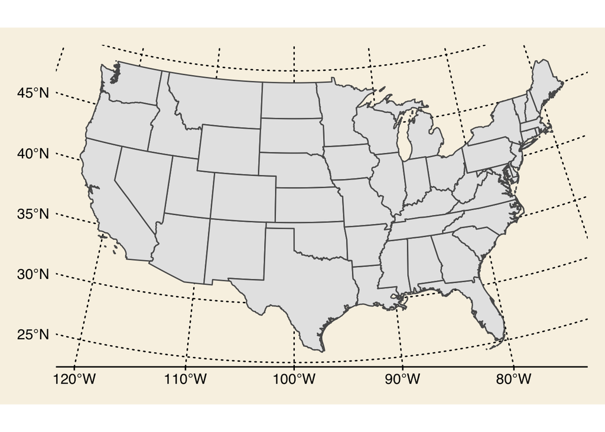

```r
USA_LCC <- "+proj=lcc +lon_0=-100 +lat_1=29.5 +lat_2=45.5"

ggplot(US_states) +
  geom_sf() +
  theme_wsj() +
  coord_sf(crs = USA_LCC)
```

## Transforming Coordinate Systems

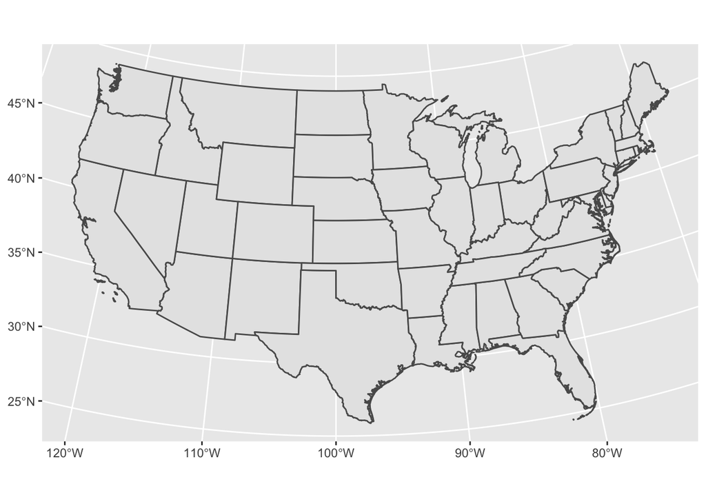

```r
states_transformed <- US_states %>%
  st_transform(crs = USA_LCC)

ggplot(states_transformed) +
  geom_sf() +
  theme_set(theme_bw())
```

## Creating a Map

I created a csv file with the following variables at the state-level :

1. Total population : tot_pop
2. Ratio of population under the poverty level : rat_pov
3. Median Income : med_income

```r
poverty_us <- read_csv("state2018.csv")

poverty_states <-states_transformed %>%
  left_join(poverty_us, by = c("name" = "NAME")) %>%
  select(name, tot_popE, rat_pov, med_incomeE, postal)

poverty_states <- cbind(poverty_states,
st_coordinates(st_centroid(
poverty_states$geometry)))
```

### 1. Choropleth map

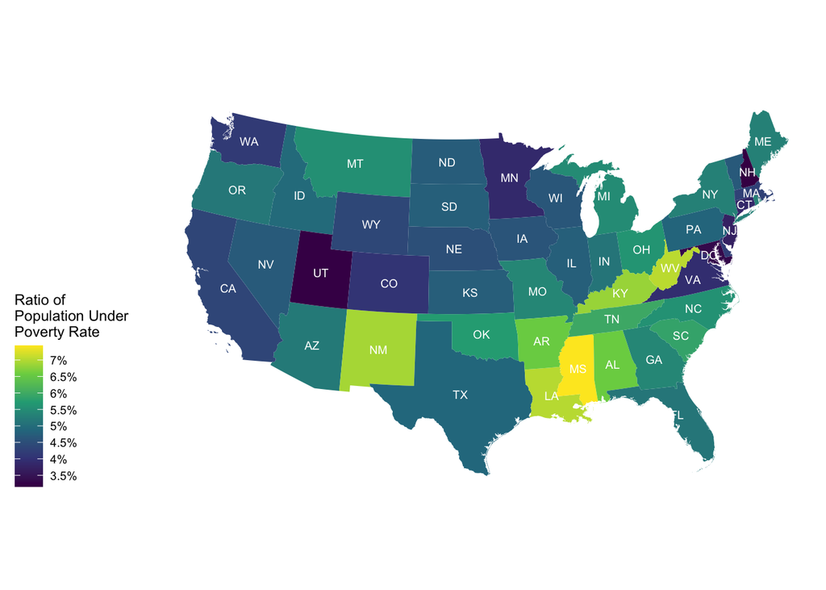

```r
ggplot(poverty_states, aes(fill = rat_pov)) +
  geom_sf(color = NA) +
  scale_fill_viridis_c(
    name = "Ratio of\nPopulation Under\nPoverty Rate",
    breaks = seq(0, 0.1, by = 0.005),
    labels = paste(seq(0, 10, by = 0.5), "%", sep = "")) +
  geom_text(aes(label = postal, x = X, y = Y),
            color = "white",
            size = 2.5,
            check_overlap = TRUE) +

  theme_map() +
  theme(legend.background = element_blank(),
        legend.direction = "vertical",
        legend.position = "left")
```

According to this map, Mississippi seems to have the highest ratio of population under the poverty rate. Following states are New Mexico, West Virginia, Louisiana, Kentucky, Arkansas, and Alabama.

### 2. Cartograms

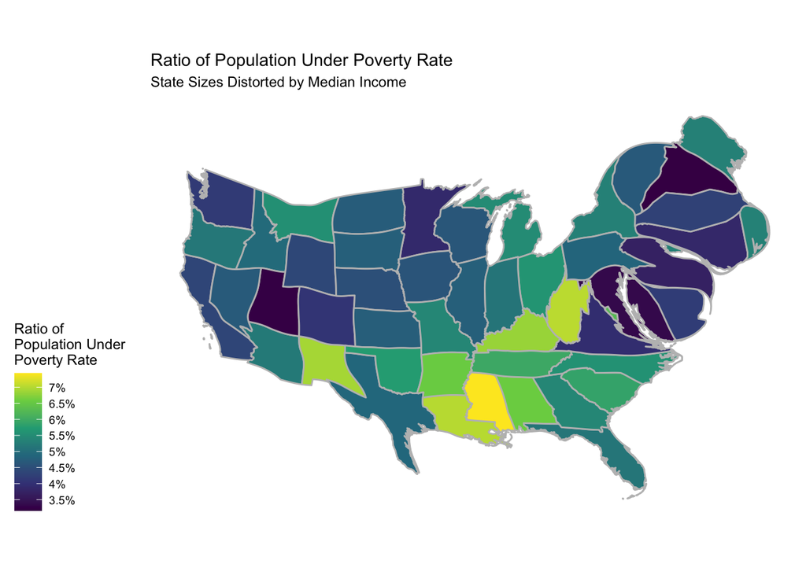

```r
poverty_cartogram_cont <- poverty_states %>%
  cartogram_cont("med_incomeE")

ggplot(poverty_cartogram_cont, aes(fill = rat_pov)) +
  geom_sf(color = "gray") +
  scale_fill_viridis_c(
    name = "Ratio of\nPopulation Under\nPoverty Rate",
    breaks = seq(0, 0.1, by = 0.005),
    labels = paste(seq(0, 10, by = 0.5), "%", sep = "")) +
  theme_map() +
  theme(legend.background = element_blank(),
        legend.direction = "vertical",
        legend.position = "left") +
  labs(title= "Ratio of Population Under Poverty Rate",
       subtitle = "State Sizes Distorted by Median Income")
```

I distorted the sizes of each state by their median income. This is to see through this map whether there is a relationship between the median income and the ratio of population under the poverty rate. If that has a negative relationship, the size of states mentioned above such as Mississippi, New Mexico, West Virginia should shrink. As a result, new Mexico shrunk quite a lot, but the changes were not so significant in others. Meanwhile, the notable size changes happened in the states in the east coast.

### 3. Non-continuous Cartograms

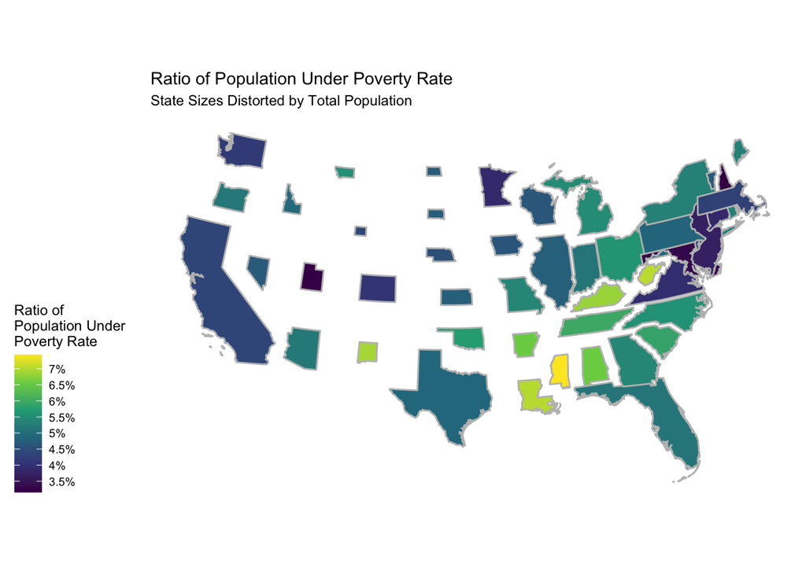

```r
poverty_cartogram_cont <- poverty_states %>%
  cartogram_ncont("tot_popE")

ggplot(poverty_cartogram_cont, aes(fill = rat_pov)) +
  geom_sf(color = "gray") +
  scale_fill_viridis_c(
    name = "Ratio of\nPopulation Under\nPoverty Rate",
    breaks = seq(0, 0.1, by = 0.005),
    labels = paste(seq(0, 10, by = 0.5), "%", sep = "")) +
  theme_map() +
  theme(legend.background = element_blank(),
        legend.direction = "vertical",
        legend.position = "left") +
  labs(title= "Ratio of Population Under Poverty Rate",
       subtitle = "State Sizes Distorted by Total Population")
```

I distorted the sizes of each state by their total population. This was basically to visualize the general relationship between the total population and the ratio of population under poverty rate.

### 4. Proportional symbol map

```r
poverty_centroids <- poverty_states %>%
  st_centroid()
```

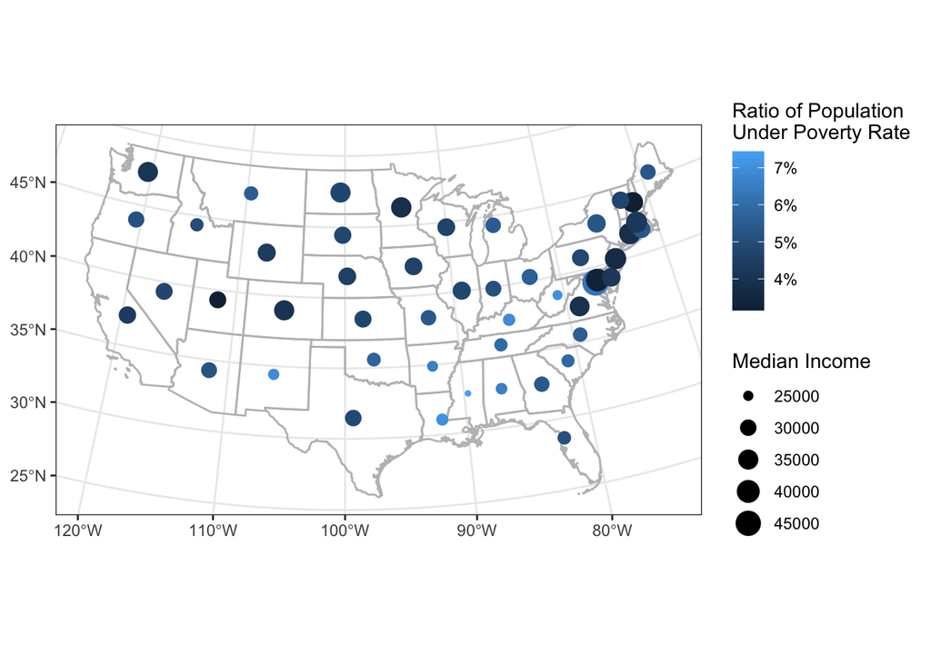

```r
ggplot(states_transformed) +
  theme_set(theme_economist()) +
  geom_sf(fill = NA, color = "gray") +
  geom_sf(data = poverty_centroids,
          aes(size = med_incomeE, color = rat_pov)) +

  scale_color_continuous(name = "Ratio of Population\nUnder Poverty Rate",
    breaks = seq(0, 0.1, by = 0.01),
    labels = paste(seq(0, 10, by = 1), "%", sep = "")) +

  scale_size_continuous(name = "Median Income")
```

This is a different way of visualization with exactly the same data of the cartogram above (which integrated the poverty rate and median income).